# Easy themes for your plots

## Configuration

Before using this package you’ll want to configure color codes and palette combinations. This is accomplished on the `R/config.yml` file using standard yaml formatting (including a trailing newline). This needs to be performed the package is installed. Required components are:

1. colors: define hex codes that correspond to specific hex color codes. If you’re looking for inspiration there are plenty of [tools to help](https://coolors.co/f58220-7ac143-591f00-ffd051-f7a964-61ab33-b84000-ffe499). These will provide both the basis for palettes you define but also be available to use manually.
2. palettes: named collections of colors defined in the colors section. We minimally require a *main* palette and support as many more as desired.

[output not shown]

## Quick start

These examples demonstrate usage of two functions (scales) that can be used to modify color schemes of a ggplot. Common params for these include:

- *palette* Name of a configured palette of colors
- *reverse* Boolean if you want to reverse the order of configured colors
- *discrete* Boolean indicating whether color aesthetic is discrete. Alternatively it will create a scale appropriate for continuous values.

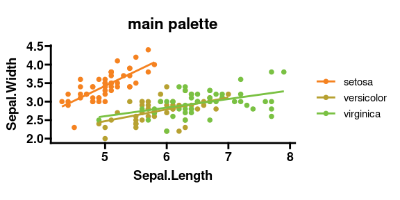

```r
library(EasyBranding)
library(ggplot2)
library(ggprism)

theme_set(theme_prism() + theme(aspect.ratio = 0.4))
p <- ggplot(iris, aes(x=Sepal.Length, y=Sepal.Width, color = Species)) +
  geom_point(size = 2) +
  geom_smooth(formula = 'y ~ x', method = 'glm', se = F)

p + scale_color_brand() +
  labs(title='main palette')
```

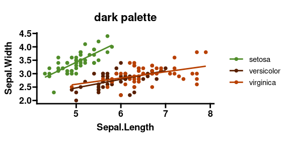

```r
p + scale_color_brand(palette = 'dark') +
  labs(title='dark palette')
```

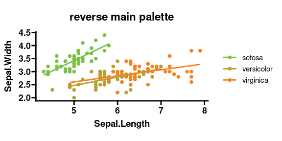

```r
p + scale_color_brand(reverse = T) +
  labs(title='reverse main palette')
```

In this series we demonstrate how palettes are created when datasets require more colors than those defined in a palette. This is typically accomplished by interpolating intermediate values, therefore when a palette is defined by 2 values the colors are all intermediate those two, then more are specified then colors are interpolated along those specifications.

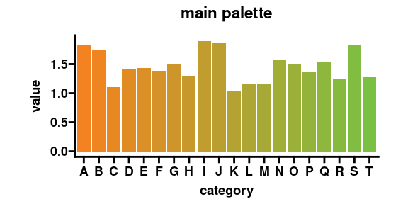

```r
df <- data.frame(category = LETTERS[1:20],
                 value = runif(20)+1)
p <- ggplot(df, aes(category, value, fill = category)) +
  geom_col()
p + scale_fill_brand() +
  labs(title='main palette') +
  theme(legend.position = 'none')
```

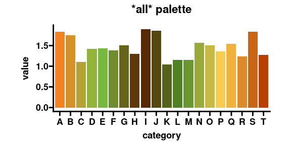

```r
p + scale_fill_brand(palette = "all") +
  labs(title='*all* palette') +
  theme(legend.position = 'none')
```